# contingency table - chi-square

PhD Flavio Lichtenstein

2071, July 17th

## Contingency table, statistics and independence

Here we will present a first study about Contingency Table. The classes belonging to the table are compared, and we will infer it they are independent. The statistics that will be used is the chi-square statistics, or better, chi-square hypothesis test.

### Contingency Table

Contingency table is a frequency table usually grouping classes versus properpties.  
Examples:  
. Lab tests versus positive/negative results  
. Gender versus leisures  
. Student Grades versus studied hours  
. Politic groups versus acceptance/rejectance  
All following distributions (tables) are categorical variables and their values are discrete (integers).

### Contingency Table 2x3 - One-way table

$$\begin{array}
{rrr}
gender & Dance & Sports & TV \\
Men & 2 & 10 & 8 \\
Women & 16 & 6 & 8
\end{array}$$

In this case the class is gender = {“men”, “women”} and properties are leisures = {“dance”, “sports”, “tv”}. As can be seen this matrix has 2 lines and 3 columns (2x3).

### Contingency & Marginal Values

Here we add the row and column totals, also called marginals.

$$\begin{array}
{rrr}
gender & Dance & Sports & TV & Total \\
Men & 2 & 10 & 8 & 20 \\
Women & 16 & 6 & 8 & 30 \\
Total & 18 & 16 & 16& 50
\end{array}$$

### Contingency Table 2x2

$$\begin{array}
{rrr}
gender & Smoke & Non-smoke & Total \\
Men & 72 & 44 & 116 \\
Women & 34 & 53 & 87 \\
Total & 106 & 97 & 203
\end{array}$$

from: https://www.youtube.com/watch?v=W95BgQCp_rQ

### Contingency Table - Marginals

$$\begin{array}
{rrr}
gender & Smoke & Non-smoke & Marginal Row \\
Men & X_{1,1} & X_{1,2} & X_1\ or\ X_{men} \\
Women & X_{2,1} & X_{2,2} & X_2\ or\ X_{women} \\
Total & X_{smoke} & X_{non} & Total
\end{array}$$
Here X1 and X2 are line totals ou line marginals. And Xsmoke and Xnon are column totals or column marginals.

### Contingency Table is a Graph

This kind of table is also a graph, used in conditional probabilities. See how we can draw such a graph:

- Conditional: gender

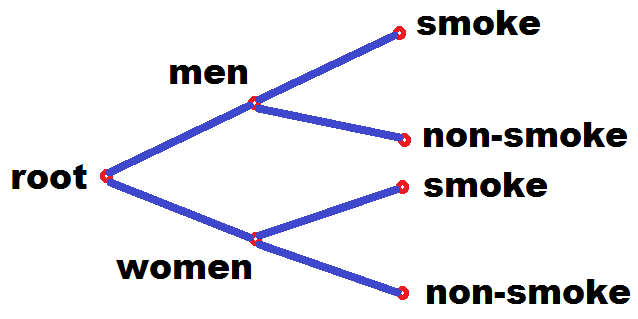

Conditional: men x women

- Conditional: smoke

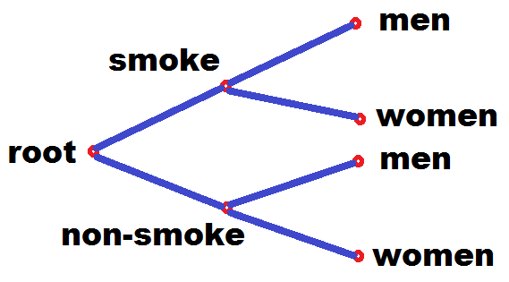

Conditional: smoke x non-smoke

## Independence

If two sets are independent

$$A\ \bot\ B$$
then

$$A+B = A\ \bigcup\ B$$

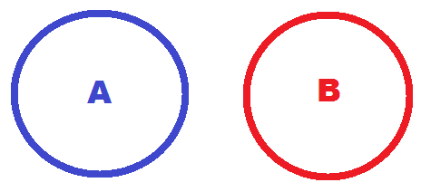

otherwise,

$$A+B = A\ \bigcup\ B\ -\ A\ \bigcap\ B$$

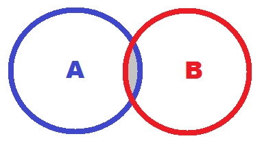

From statistics and set-theory we know that if two probabilities are independent the joint probability is,

$$p_{i,j} = p_i * p_j$$

and, if they are not independent, then

Lets use R to simulate these tables, calculate the expected values (for an independent distribution), and thereafter calculate chi-square and goodness of fit statistics.

```r
dfObs = matrix(c(72,44, 34,53), byrow=T, nrow=2, ncol=2)

rownames(dfObs) = c("men", "women")
colnames(dfObs) = c("smoke", "not.smoke")

print(dfObs)
```

```
##       smoke not.smoke
## men      72        44
## women    34        53
```

Then we can calculate the marginal probabilies,

```r
tot.men = dfObs[1,1] + dfObs[1,2]
tot.wom = dfObs[2,1] + dfObs[2,2]

tot.smo = dfObs[1,1] + dfObs[2,1]
tot.not = dfObs[1,2] + dfObs[2,2]

total = tot.men + tot.wom

perc.men = tot.men / total
perc.wom = tot.wom / total
perc.tot = perc.men + perc.wom

perc.smo = tot.smo / total
perc.not = tot.not / total
perc.tot2 = perc.smo + perc.not


m2 = cbind(dfObs, tot.gender = c(tot.men, tot.wom), perc.gender = c(perc.men, perc.wom))
m2 = rbind(m2, tot.prop=data.frame(smoke=tot.smo, not.smoke=tot.not, tot.gender=total, perc.gender=perc.tot))
m2 = rbind(m2, perc.prop=data.frame(smoke=perc.smo, not.smoke=perc.not, tot.gender=perc.tot2, perc.gender=perc.tot))

options(digits=2)
print(m2)
```

```
##            smoke not.smoke tot.gender perc.gender
## men        72.00     44.00        116        0.57
## women      34.00     53.00         87        0.43
## tot.prop  106.00     97.00        203        1.00
## perc.prop   0.52      0.48          1        1.00
```

- Now we have quantitative and percentage marginals,

– Quantitative

```r
m2 = cbind(dfObs, tot.gender = c(tot.men, tot.wom))
m2 = rbind(m2, tot.prop=data.frame(smoke=tot.smo, not.smoke=tot.not, tot.gender=total))

print(m2)
```

```
##          smoke not.smoke tot.gender
## men         72        44        116
## women       34        53         87
## tot.prop   106        97        203
```

– Percentage

```r
m2 = cbind(dfObs, perc.gender = c(perc.men, perc.wom))
m2 = rbind(m2, perc.prop=data.frame(smoke=perc.smo, not.smoke=perc.not, perc.gender=perc.tot2))

print(m2)
```

```
##           smoke not.smoke perc.gender
## men       72.00     44.00        0.57
## women     34.00     53.00        0.43
## perc.prop  0.52      0.48        1.00
```

Now that we have calculated the marginal totals and the marginal percentages, we are able to calculate the independent distribution matrix !

$$p_{i,j} = p_i * p_j$$
where, pi and pj are the marginal distribution for a row and for a column, respectively.

```r
dfExp = matrix(c(perc.men*perc.smo, perc.men*perc.not, perc.wom*perc.smo, perc.wom*perc.not), byrow=T, nrow=2, ncol=2)

options(digits=3)
print(dfExp)
```

```
##       [,1]  [,2]
## [1,] 0.298 0.273
## [2,] 0.224 0.205
```

```r
sum(dfExp)
```

```
## [1] 1
```

As expected, now we can calculate the Expected Values. But what is “expected values”. Expected values are values expected if the distribution behaves as an independente distribution (men and women don’t interact concerning smoking). Therefore, we should only multiply the indpendent probability matrix times the total.

```r
dfExp = matrix(c(perc.men*perc.smo, perc.men*perc.not, perc.wom*perc.smo, perc.wom*perc.not), byrow=T, nrow=2, ncol=2)
dfExp = round(dfExp * total, 1)

options(digits=1)

cat("The expected values for independent distribution is ...")
```

```
## The expected values for independent distribution is ...
```

```r
print(dfExp)
```

```
##      [,1] [,2]
## [1,]   61   55
## [2,]   45   42
```

```r
all.equal(total, sum(dfExp))
```

```
## [1] TRUE
```

```r
total == sum(dfExp)
```

```
## [1] TRUE
```

Now we have a good question! Is the original distribution quite similar to the expected independent distribution? If yes, we can say that that man and women don’t interact themselves concerning to smoking. Otherwise they interact having a bias.

This is the classical approach for a Test Hypothesis. The test that is chosen in this case is the chi-square test.